# Untitled

Jian(Frank)

27/01/2022

## Import data

```r
data <- fread("Data/cleaned.csv")
# clean data
# data[, Item_Fat_Content:=ifelse(Item_Fat_Content %in% c("low fat", "LF", "Low Fat"),
#                                 "Low Fat",
#                                 ifelse(Item_Fat_Content == "reg", "Regular", Item_Fat_Content))]
```

# Goals:

- Build a model to predict the number of sales (Item_Outlet_Sales) using the available features.
- Gain insights about the number of sales.
- Pretend you are presenting the results to an executive level manager of one of our clients.

item_outlet_sales ~ f(x)

```
##  [1] "Item_Identifier"           "Item_Weight"
##  [3] "Item_Fat_Content"          "Item_Visibility"
##  [5] "Item_Type"                 "Item_MRP"
##  [7] "Outlet_Identifier"         "Outlet_Establishment_Year"
##  [9] "Outlet_Size"               "Outlet_Location_Type"
## [11] "Outlet_Type"               "Item_Outlet_Sales"
```

```
##       Item_Identifier Item_Fat_Content             Item_Type Outlet_Identifier
##    1:           FDA15          Low Fat                 Dairy            OUT049
##    2:           DRC01          Regular           Soft Drinks            OUT018
##    3:           FDN15          Low Fat                  Meat            OUT049
##    4:           FDX07          Regular Fruits and Vegetables            OUT010
##    5:           NCD19          Low Fat             Household            OUT013
##   ---
## 8519:           FDF22          Low Fat           Snack Foods            OUT013
## 8520:           FDS36          Regular          Baking Goods            OUT045
## 8521:           NCJ29          Low Fat    Health and Hygiene            OUT035
## 8522:           FDN46          Regular           Snack Foods            OUT018
## 8523:           DRG01          Low Fat           Soft Drinks            OUT046
##       Outlet_Size       Outlet_Type
##    1:      Medium Supermarket Type1
##    2:      Medium Supermarket Type2
##    3:      Medium Supermarket Type1
##    4:       Small     Grocery Store
##    5:        High Supermarket Type1
##   ---
## 8519:        High Supermarket Type1
## 8520:      Medium Supermarket Type1
## 8521:       Small Supermarket Type1
## 8522:      Medium Supermarket Type2
## 8523:       Small Supermarket Type1
```

```
## $Item_Fat_Content
## [1] "Low Fat" "Regular"
##
## $Item_Type
##  [1] "Dairy"                 "Soft Drinks"           "Meat"
##  [4] "Fruits and Vegetables" "Household"             "Baking Goods"
##  [7] "Snack Foods"           "Frozen Foods"          "Breakfast"
## [10] "Health and Hygiene"    "Hard Drinks"           "Canned"
## [13] "Breads"                "Starchy Foods"         "Others"
## [16] "Seafood"
##
## $Outlet_Identifier
##  [1] "OUT049" "OUT018" "OUT010" "OUT013" "OUT027" "OUT045" "OUT017" "OUT046"
##  [9] "OUT035" "OUT019"
##
## $Outlet_Size
## [1] "Medium" "Small"  "High"
##
## $Outlet_Type
## [1] "Supermarket Type1" "Supermarket Type2" "Grocery Store"
## [4] "Supermarket Type3"
```

## The top 10 popular Product

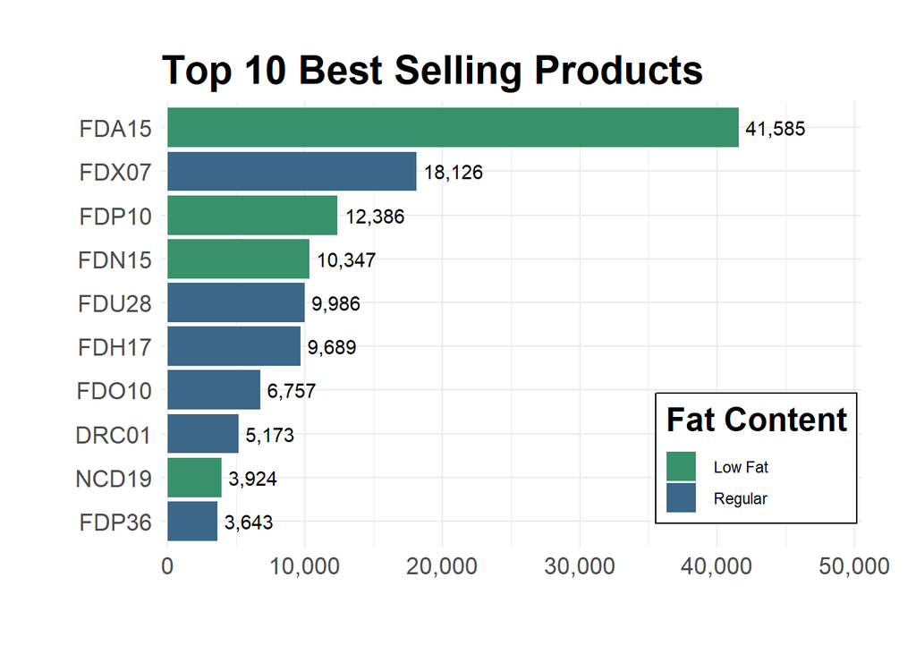

## The most popular Product Type

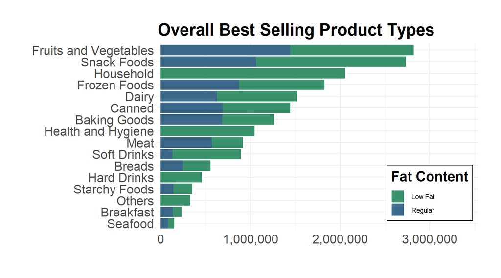

## The most popular store

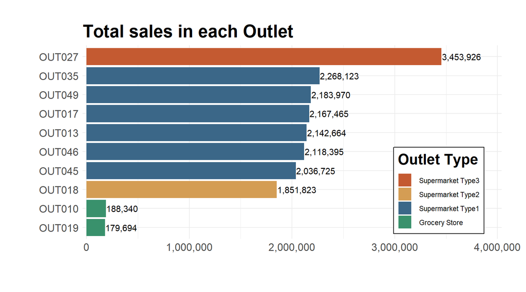

## pattern between item mpr and log10 sales

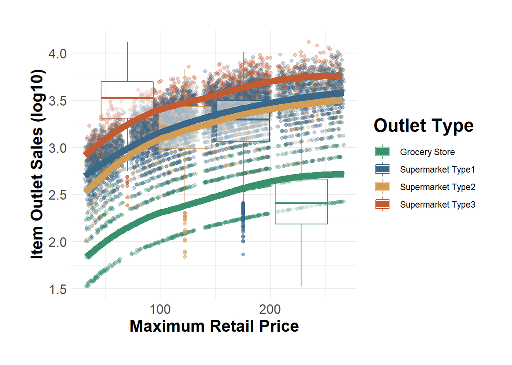

```
##       Item_Identifier Item_Fat_Content             Item_Type Outlet_Identifier
##    1:           FDA15          Low Fat                 Dairy            OUT049
##    2:           DRC01          Regular           Soft Drinks            OUT018
##    3:           FDN15          Low Fat                  Meat            OUT049
##    4:           FDX07          Regular Fruits and Vegetables            OUT010
##    5:           NCD19          Low Fat             Household            OUT013
##   ---
## 8519:           FDF22          Low Fat           Snack Foods            OUT013
## 8520:           FDS36          Regular          Baking Goods            OUT045
## 8521:           NCJ29          Low Fat    Health and Hygiene            OUT035
## 8522:           FDN46          Regular           Snack Foods            OUT018
## 8523:           DRG01          Low Fat           Soft Drinks            OUT046
##       Outlet_Size       Outlet_Type
##    1:      Medium Supermarket Type1
##    2:      Medium Supermarket Type2
##    3:      Medium Supermarket Type1
##    4:       Small     Grocery Store
##    5:        High Supermarket Type1
##   ---
## 8519:        High Supermarket Type1
## 8520:      Medium Supermarket Type1
## 8521:       Small Supermarket Type1
## 8522:      Medium Supermarket Type2
## 8523:       Small Supermarket Type1
```

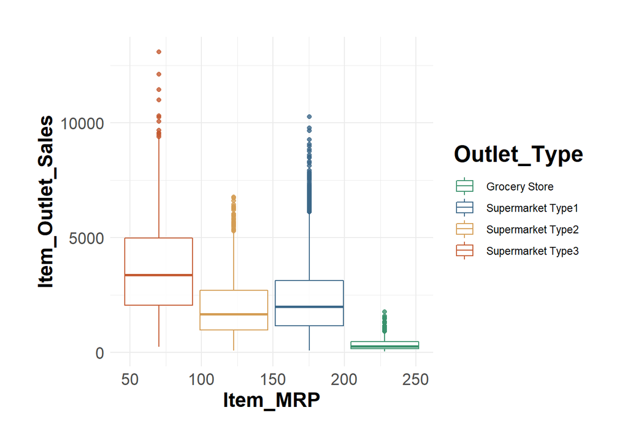

**Type1 and 2 can be combined into one class.**

## outlet type sales generation

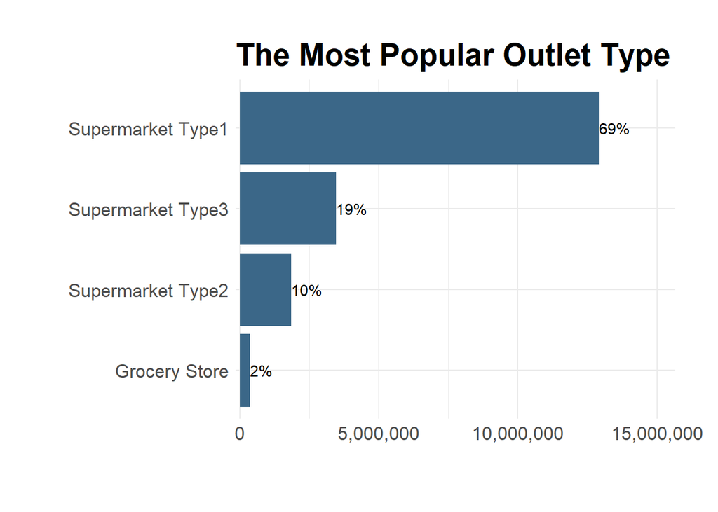

```
## [1] 0.007944202
```

```
## [1] 34539.26
```

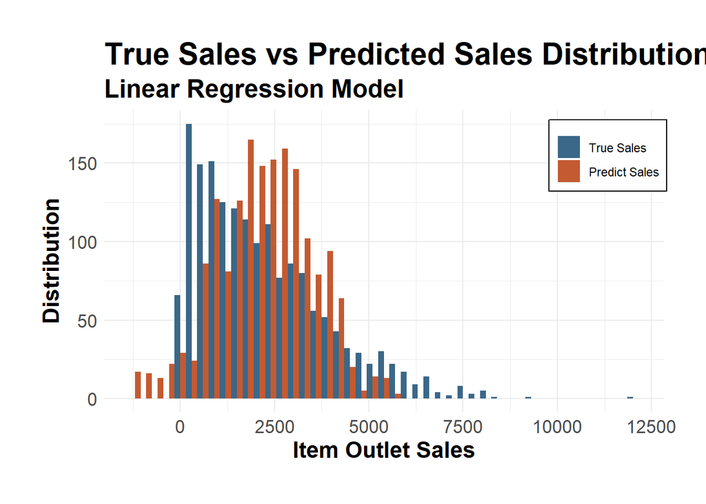

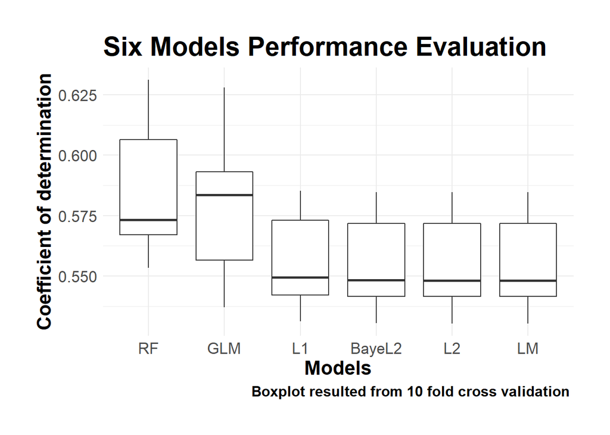

## visual glm features

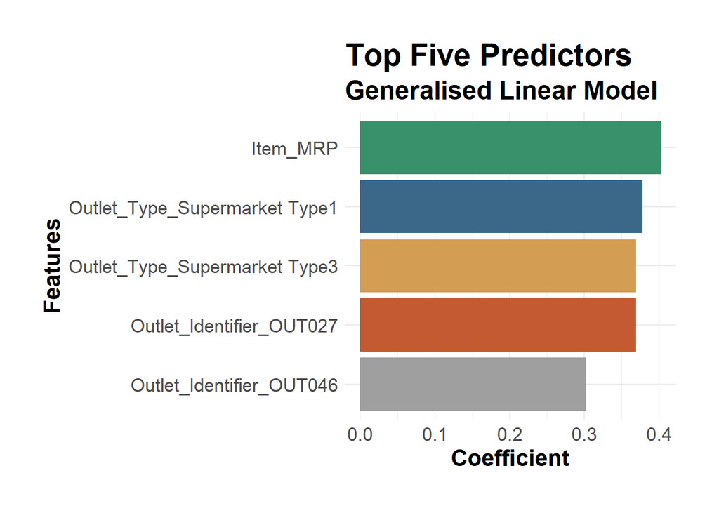

## visual rf grid search

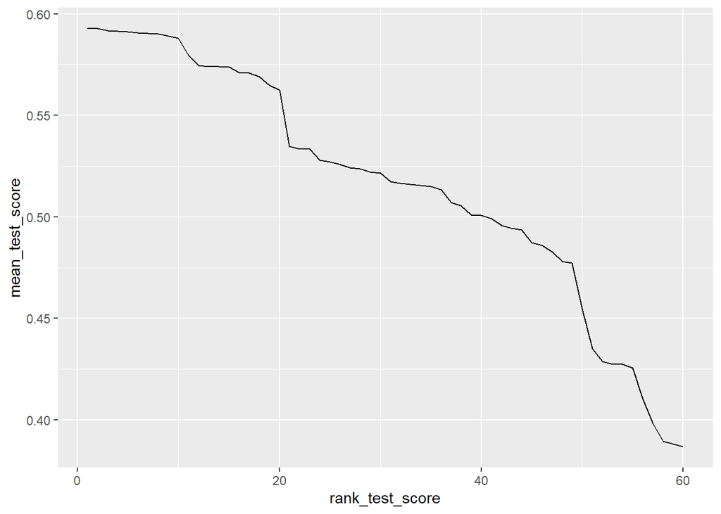

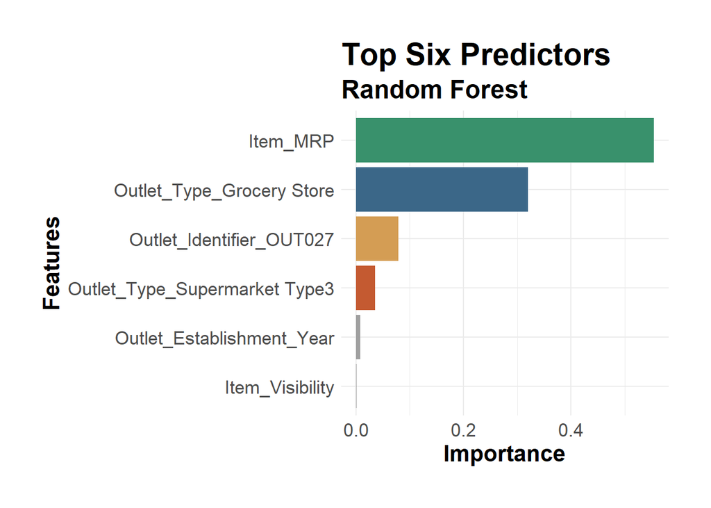

## Why store 10 and 19 are so small on sales?

```
##      Item_Identifier Item_Weight Item_Fat_Content Item_Visibility
##   1:           FDP10    12.85765          Low Fat      0.12746986
##   2:           DRI11    12.85765          Low Fat      0.03423768
##   3:           FDW12    12.85765          Regular      0.03539992
##   4:           FDV20    12.85765          Regular      0.05951181
##   5:           FDX10    12.85765          Regular      0.12311145
##  ---
## 931:           NCS41    12.85765          Low Fat      0.05318521
## 932:           DRK37    12.85765          Low Fat      0.04379158
## 933:           DRG13    12.85765          Low Fat      0.03700608
## 934:           NCN14    12.85765          Low Fat      0.09147267
## 935:           NCN18    12.85765          Low Fat      0.12411073
##                  Item_Type Item_MRP Outlet_Identifier Outlet_Establishment_Year
##   1:           Snack Foods 107.7622            OUT027                      1985
##   2:           Hard Drinks 113.2834            OUT027                      1985
```

[output cut: 21 more lines]

```
## [1] "Grocery Store"
```

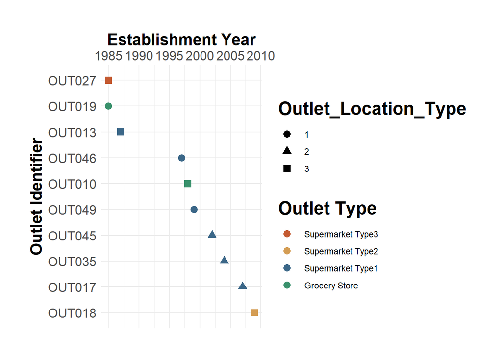

OUT010 and 019 are Grocery Stores

## Does Location affect sales?

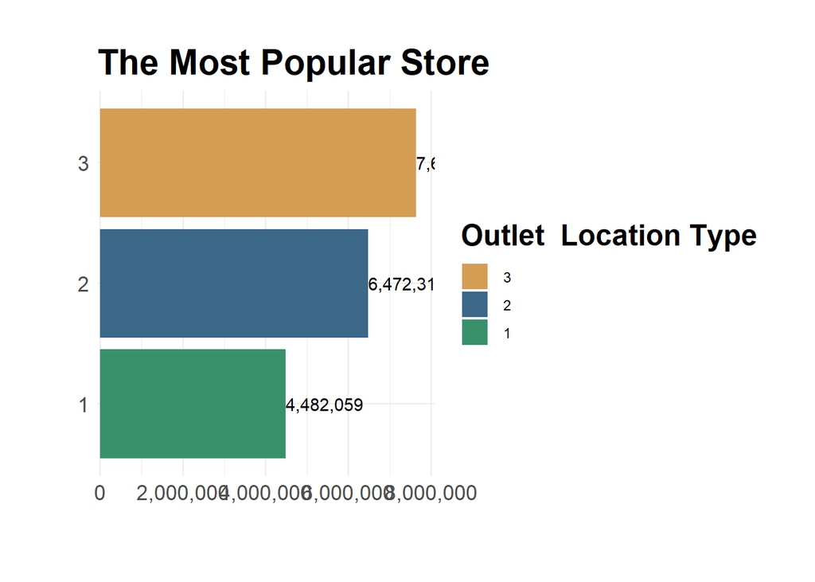

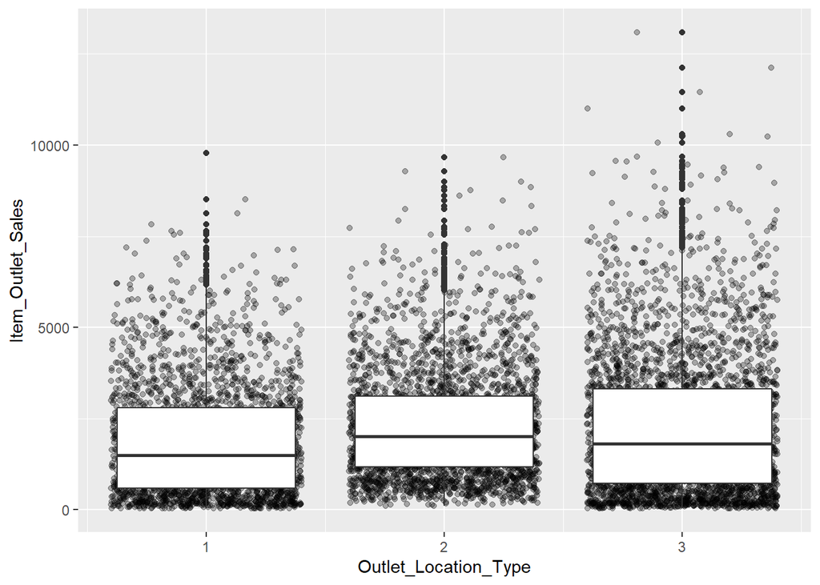

The **long tail* created the skewness, what are these?

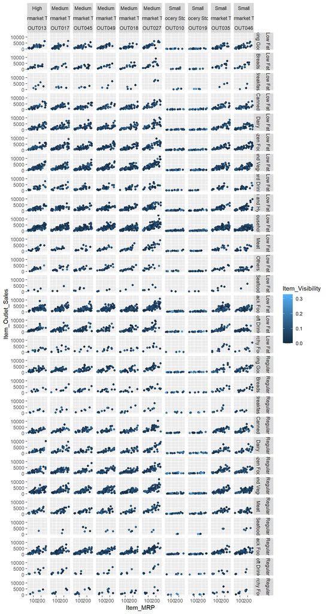

## what if filter out gocery stores?

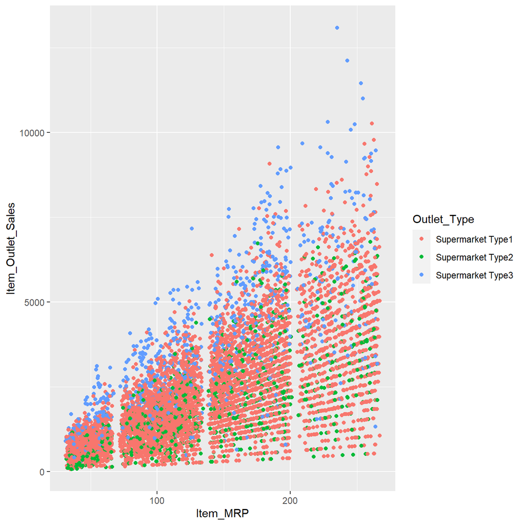

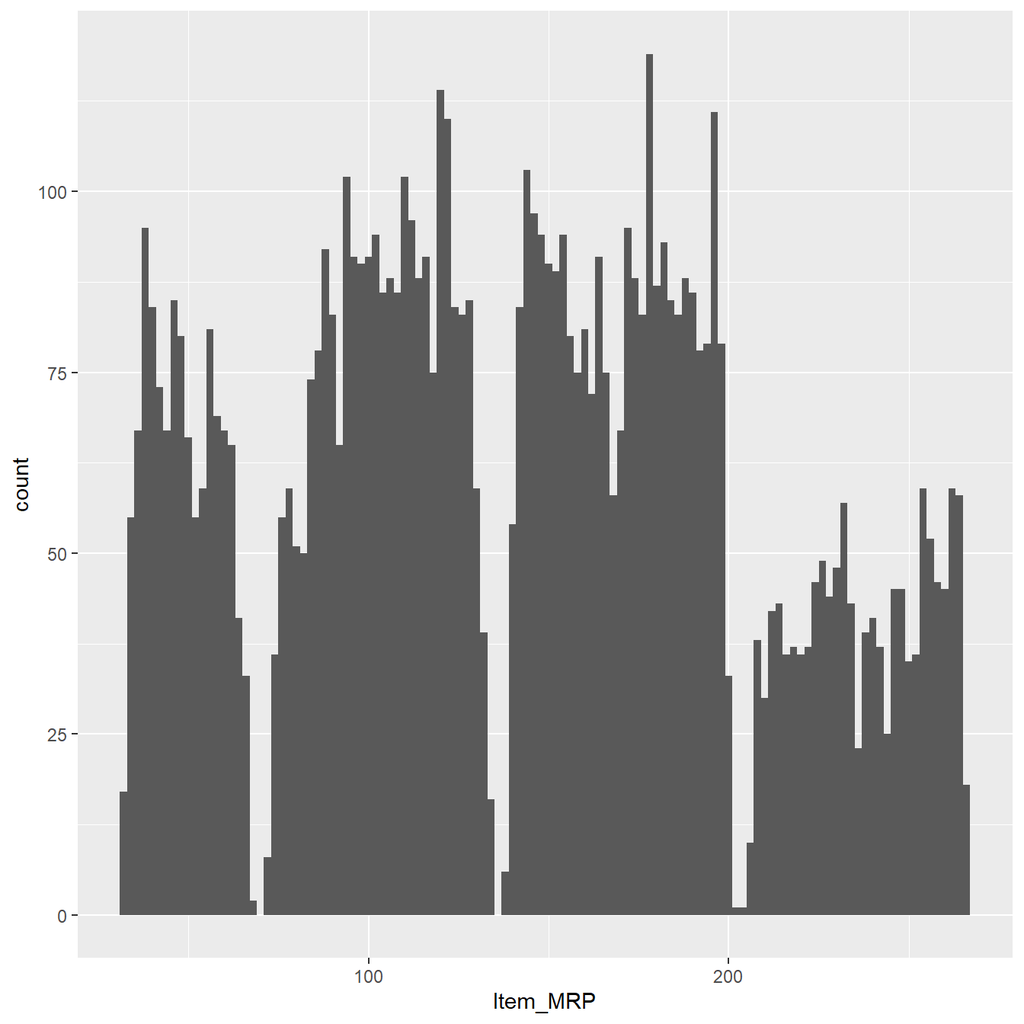

## Item visibility

```
## [1] 0.0000000 0.3283909
```

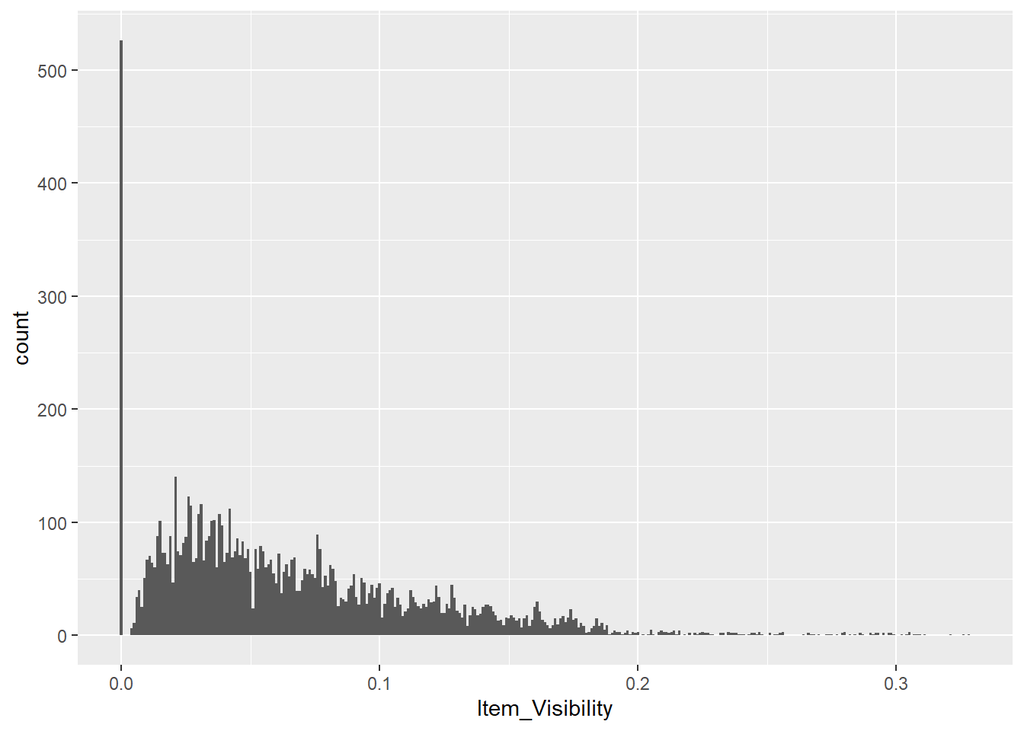

## Fat content matters?

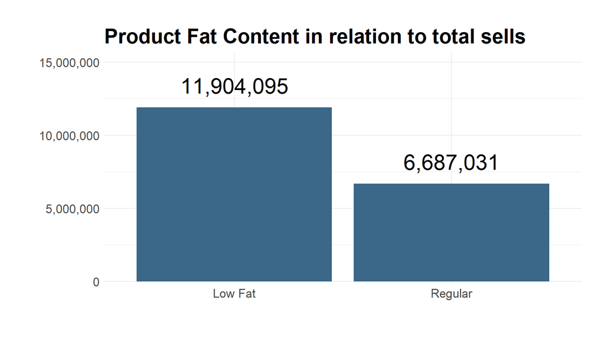

Two large categories of product types are not consumable but in low fat

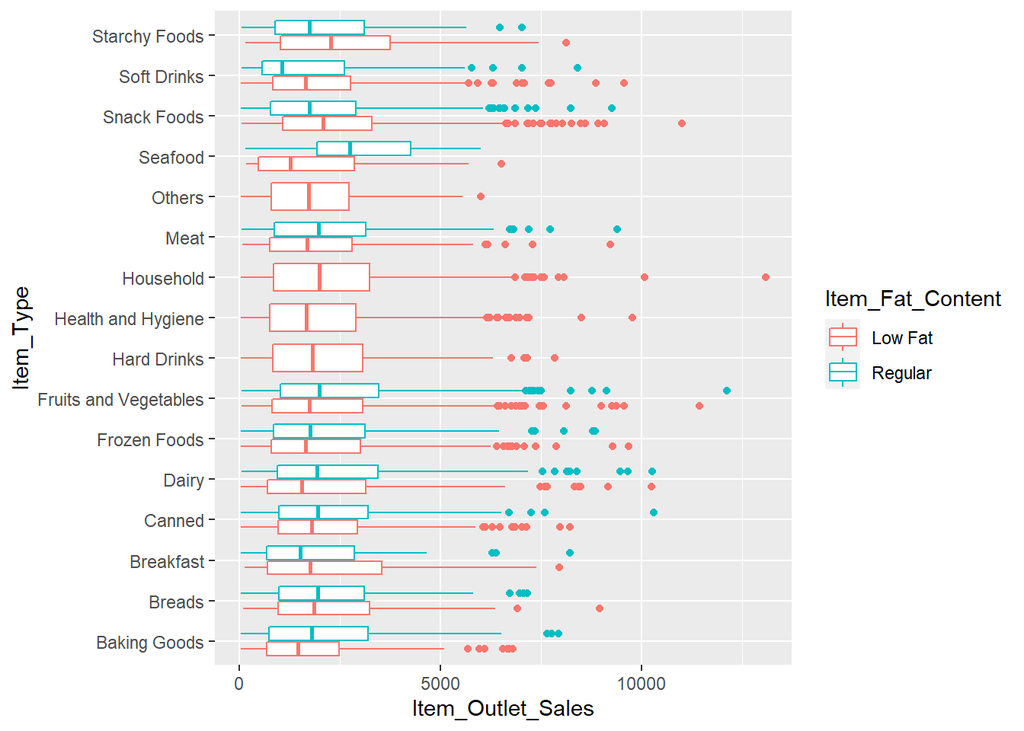

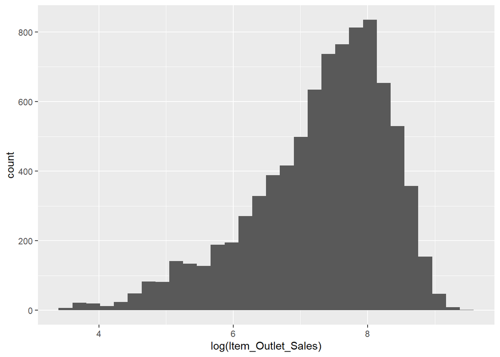

```
##    Item_Identifier Item_Weight Item_Fat_Content Item_Visibility
## 1:           FDU14    12.85765          Low Fat      0.03458436
## 2:           FDZ20    12.85765          Low Fat      0.00000000
## 3:           FDP33    12.85765          Low Fat      0.08883995
## 4:           FDF39    14.85000          Regular      0.01949505
## 5:           FDQ19    12.85765          Regular      0.01429556
## 6:           FDI50    12.85765          Regular      0.03069331
## 7:           NCE42    12.85765          Low Fat      0.01055095
## 8:           NCH18    12.85765          Low Fat      0.04444496
##                Item_Type Item_MRP Outlet_Identifier Outlet_Establishment_Year
## 1:                 Dairy 248.3750            OUT027                      1985
## 2: Fruits and Vegetables 253.0356            OUT027                      1985
## 3:           Snack Foods 254.2672            OUT027                      1985
## 4:                 Dairy 261.2910            OUT013                      1987
## 5: Fruits and Vegetables 242.6512            OUT027                      1985
## 6:                Canned 228.0352            OUT027                      1985
## 7:             Household 234.9958            OUT027                      1985
## 8:             Household 245.2802            OUT027                      1985
##    Outlet_Size Outlet_Location_Type       Outlet_Type Item_Outlet_Sales
## 1:      Medium                    3 Supermarket Type3          10236.67
## 2:      Medium                    3 Supermarket Type3          11445.10
## 3:      Medium                    3 Supermarket Type3          10993.69
## 4:        High                    3 Supermarket Type1          10256.65
## 5:      Medium                    3 Supermarket Type3          12117.56
## 6:      Medium                    3 Supermarket Type3          10306.58
## 7:      Medium                    3 Supermarket Type3          13086.96
## 8:      Medium                    3 Supermarket Type3          10072.89
```

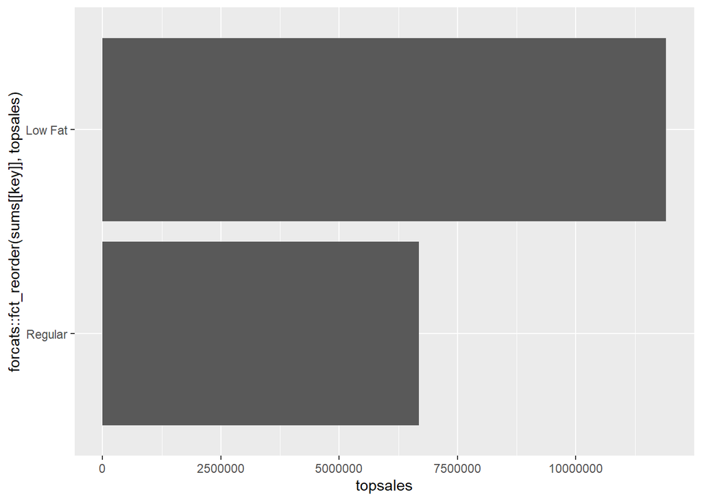

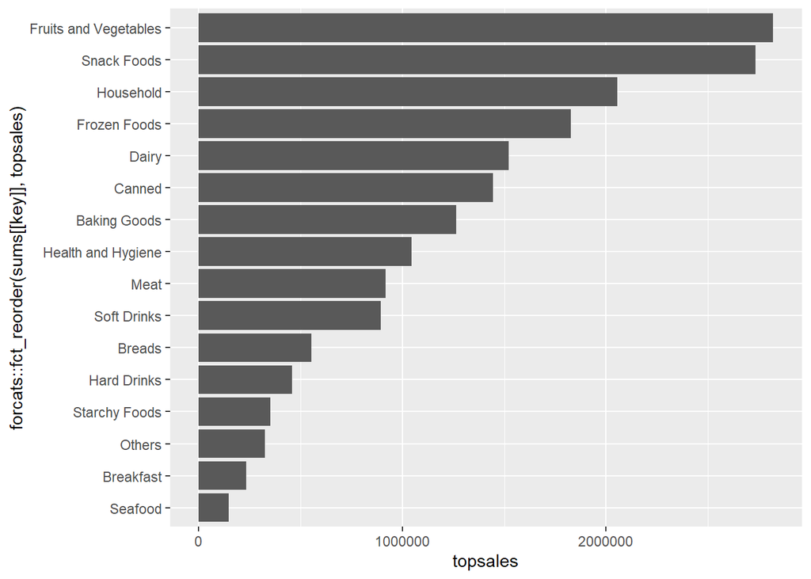

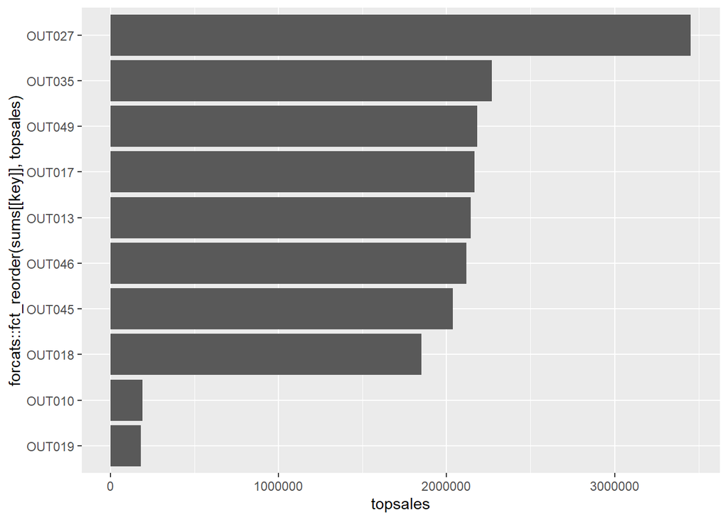

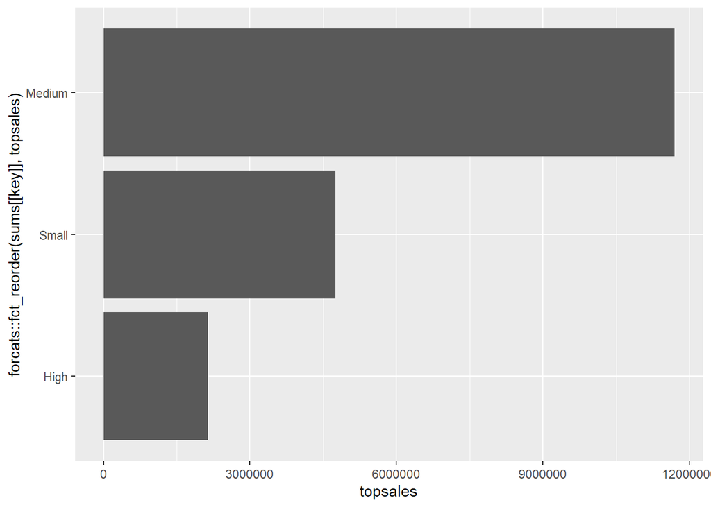

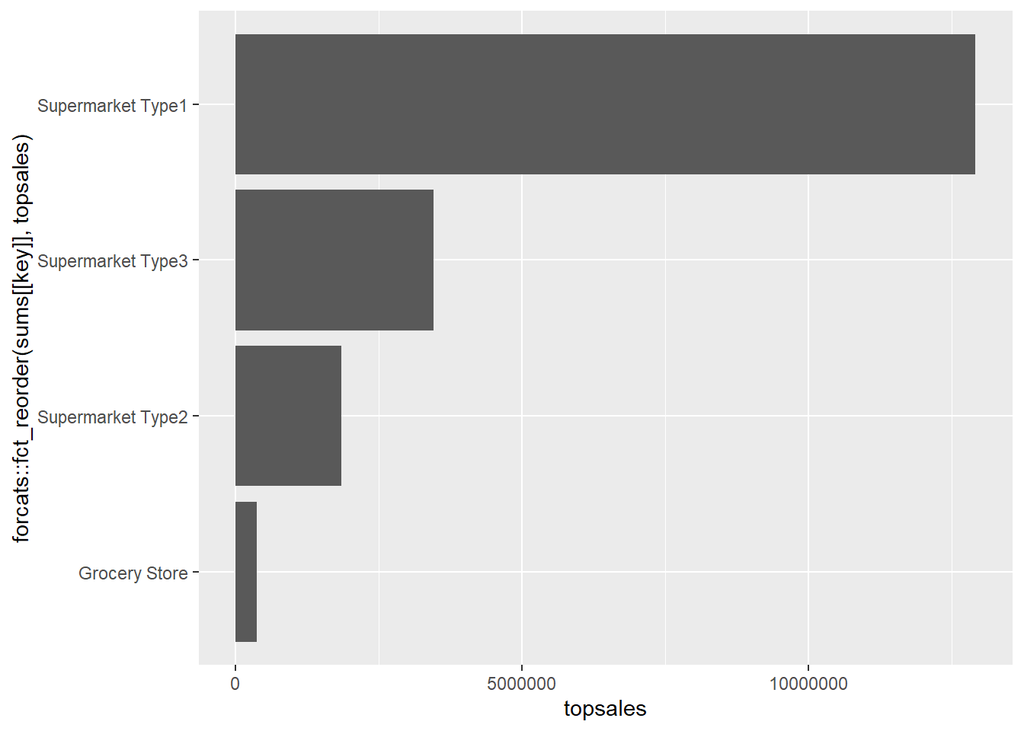

```
##      Item_Identifier Item_Weight Item_Fat_Content Item_Visibility
##   1:           DRY23    12.85765          Regular      0.19101366
##   2:           FDQ04    12.85765          Low Fat      0.14839262
##   3:           FDW24    12.85765          Low Fat      0.06565249
##   4:           FDW35    12.85765          Low Fat      0.01941580
##   5:           FDW23    12.85765          Low Fat      0.14359294
##  ---
## 120:           FDX23     6.44500          Low Fat      0.04969792
## 121:           FDG40    13.65000          Low Fat      0.06665779
## 122:           DRH59    10.80000          Low Fat      0.09780561
## 123:           FDX40    12.85765          Low Fat      0.17332421
## 124:           FDR20    20.00000          Regular      0.00000000
##                  Item_Type Item_MRP Outlet_Identifier Outlet_Establishment_Year
##   1:           Soft Drinks  42.1112            OUT019                      1985
##   2:          Frozen Foods  41.5796            OUT019                      1985
```

[output cut: 21 more lines]

Super market type 1 generate lots of sales

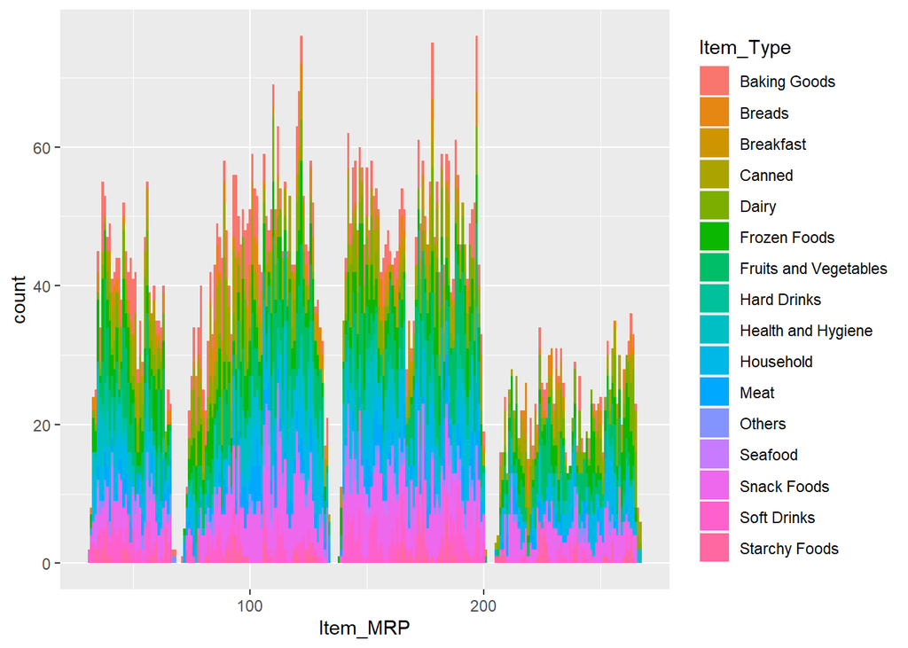

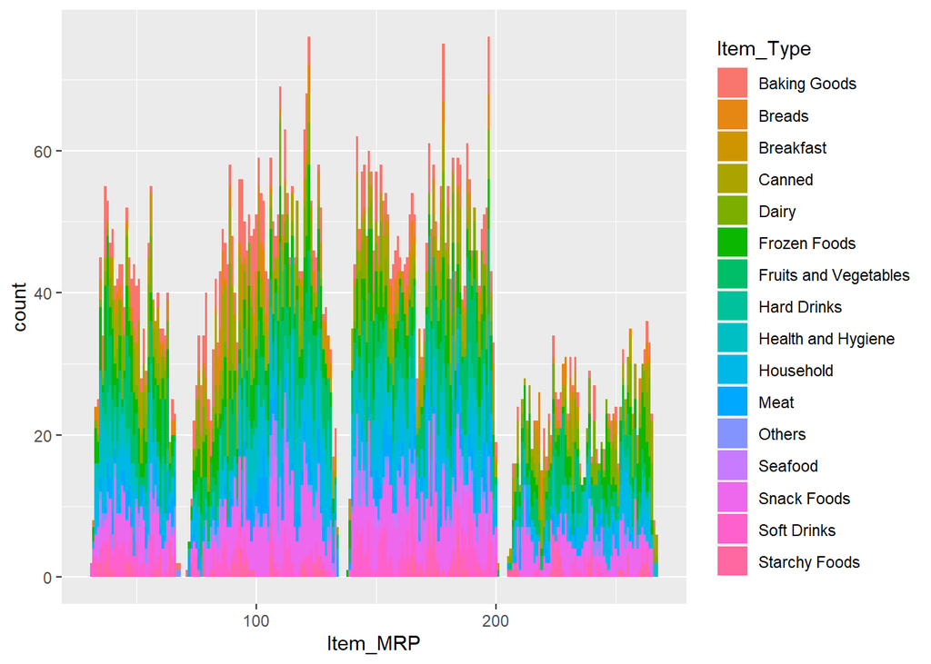

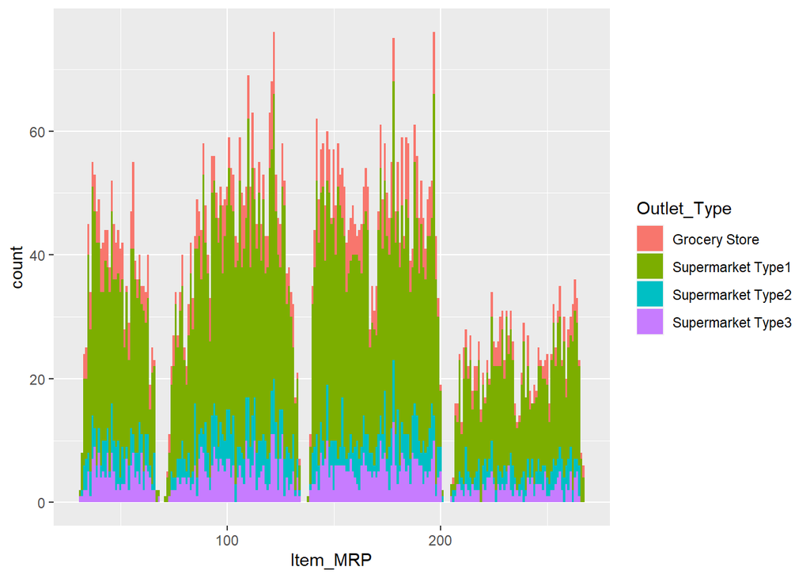

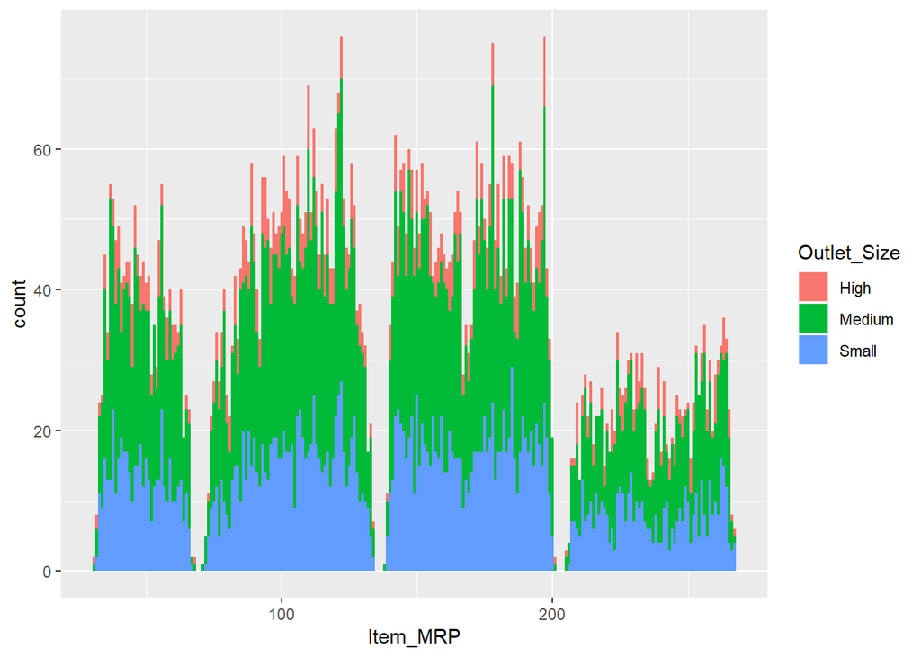